# Risk Factor Analysis

## Outcome Variable

**Outcome Variable:** pers_wasted624

## Predictor Variables

**Intervention Variable:** pers_wasted06

**Adjustment Set:**

- sex
- arm
- brthmon
- vagbrth
- single
- W_mage
- W_mhtcm
- W_mwtkg
- W_mbmi
- W_meducyrs
- W_feducyrs
- W_parity
- delta_brthmon
- delta_vagbrth
- delta_single
- delta_W_mage
- delta_W_mhtcm
- delta_W_mwtkg
- delta_W_mbmi
- delta_W_meducyrs
- delta_W_feducyrs
- delta_W_parity

## Stratifying Variables

The analysis was stratified on these variable(s):

- studyid
- country

## Data Summary

| studyid | country | pers_wasted06 | pers_wasted624 | n_cell | n |
| --- | --- | --- | --- | --- | --- |
| ki0047075b-MAL-ED | BANGLADESH | 0 | 0 | 219 | 240 |
| ki0047075b-MAL-ED | BANGLADESH | 0 | 1 | 13 | 240 |
| ki0047075b-MAL-ED | BANGLADESH | 1 | 0 | 4 | 240 |
| ki0047075b-MAL-ED | BANGLADESH | 1 | 1 | 4 | 240 |
| ki0047075b-MAL-ED | BRAZIL | 0 | 0 | 205 | 207 |
| ki0047075b-MAL-ED | BRAZIL | 0 | 1 | 1 | 207 |
| ki0047075b-MAL-ED | BRAZIL | 1 | 0 | 0 | 207 |
| ki0047075b-MAL-ED | BRAZIL | 1 | 1 | 1 | 207 |
| ki0047075b-MAL-ED | INDIA | 0 | 0 | 202 | 235 |
| ki0047075b-MAL-ED | INDIA | 0 | 1 | 18 | 235 |
| ki0047075b-MAL-ED | INDIA | 1 | 0 | 5 | 235 |
| ki0047075b-MAL-ED | INDIA | 1 | 1 | 10 | 235 |
| ki0047075b-MAL-ED | NEPAL | 0 | 0 | 231 | 235 |
| ki0047075b-MAL-ED | NEPAL | 0 | 1 | 1 | 235 |
| ki0047075b-MAL-ED | NEPAL | 1 | 0 | 2 | 235 |
| ki0047075b-MAL-ED | NEPAL | 1 | 1 | 1 | 235 |
| ki0047075b-MAL-ED | PERU | 0 | 0 | 267 | 270 |
| ki0047075b-MAL-ED | PERU | 0 | 1 | 3 | 270 |
| ki0047075b-MAL-ED | PERU | 1 | 0 | 0 | 270 |
| ki0047075b-MAL-ED | PERU | 1 | 1 | 0 | 270 |
| ki0047075b-MAL-ED | SOUTH AFRICA | 0 | 0 | 256 | 259 |
| ki0047075b-MAL-ED | SOUTH AFRICA | 0 | 1 | 0 | 259 |
| ki0047075b-MAL-ED | SOUTH AFRICA | 1 | 0 | 1 | 259 |
| ki0047075b-MAL-ED | SOUTH AFRICA | 1 | 1 | 2 | 259 |
| ki0047075b-MAL-ED | TANZANIA, UNITED REPUBLIC OF | 0 | 0 | 245 | 245 |
| ki0047075b-MAL-ED | TANZANIA, UNITED REPUBLIC OF | 0 | 1 | 0 | 245 |
| ki0047075b-MAL-ED | TANZANIA, UNITED REPUBLIC OF | 1 | 0 | 0 | 245 |
| ki0047075b-MAL-ED | TANZANIA, UNITED REPUBLIC OF | 1 | 1 | 0 | 245 |
| ki1000108-CMC-V-BCS-2002 | INDIA | 0 | 0 | 307 | 370 |
| ki1000108-CMC-V-BCS-2002 | INDIA | 0 | 1 | 11 | 370 |

[output cut: 90 more lines]

The following strata were considered:

- studyid: ki0047075b-MAL-ED, country: BANGLADESH
- studyid: ki0047075b-MAL-ED, country: BRAZIL
- studyid: ki0047075b-MAL-ED, country: INDIA
- studyid: ki0047075b-MAL-ED, country: NEPAL
- studyid: ki0047075b-MAL-ED, country: PERU
- studyid: ki0047075b-MAL-ED, country: SOUTH AFRICA
- studyid: ki0047075b-MAL-ED, country: TANZANIA, UNITED REPUBLIC OF
- studyid: ki1000108-CMC-V-BCS-2002, country: INDIA
- studyid: ki1000108-IRC, country: INDIA
- studyid: ki1000109-EE, country: PAKISTAN
- studyid: ki1000109-ResPak, country: PAKISTAN
- studyid: ki1000304b-SAS-CompFeed, country: INDIA
- studyid: ki1000304b-SAS-FoodSuppl, country: INDIA
- studyid: ki1017093-NIH-Birth, country: BANGLADESH
- studyid: ki1017093b-PROVIDE, country: BANGLADESH
- studyid: ki1017093c-NIH-Crypto, country: BANGLADESH
- studyid: ki1066203-TanzaniaChild2, country: TANZANIA, UNITED REPUBLIC OF
- studyid: ki1101329-Keneba, country: GAMBIA
- studyid: ki1112895-Guatemala BSC, country: GUATEMALA
- studyid: ki1113344-GMS-Nepal, country: NEPAL
- studyid: ki1114097-CMIN, country: BANGLADESH
- studyid: ki1114097-CONTENT, country: PERU
- studyid: ki1119695-PROBIT, country: BELARUS
- studyid: ki1126311-ZVITAMBO, country: ZIMBABWE
- studyid: ki1135781-COHORTS, country: GUATEMALA
- studyid: ki1135781-COHORTS, country: INDIA
- studyid: ki1135781-COHORTS, country: PHILIPPINES
- studyid: ki1148112-LCNI-5, country: MALAWI
- studyid: kiGH5241-JiVitA-3, country: BANGLADESH
- studyid: kiGH5241-JiVitA-4, country: BANGLADESH

### Dropped Strata

Some strata were dropped due to rare outcomes:

- studyid: ki0047075b-MAL-ED, country: BANGLADESH
- studyid: ki0047075b-MAL-ED, country: BRAZIL
- studyid: ki0047075b-MAL-ED, country: NEPAL
- studyid: ki0047075b-MAL-ED, country: PERU
- studyid: ki0047075b-MAL-ED, country: SOUTH AFRICA
- studyid: ki0047075b-MAL-ED, country: TANZANIA, UNITED REPUBLIC OF
- studyid: ki1112895-Guatemala BSC, country: GUATEMALA
- studyid: ki1114097-CMIN, country: BANGLADESH
- studyid: ki1114097-CONTENT, country: PERU

## Methods Detail

We’re interested in the causal parameters $E[Y_a]$ for all values of $a \in \mathcal{A}$. These parameters represent the mean outcome if, possibly contrary to fact, we intervened to set all units to have $A=a$. Under the randomization and positivity assumptions, these are identified by the statistical parameters $\psi_a=E_W[E_{Y|A,W}(Y|A=a,W)]$. In addition, we’re interested in the mean of $Y$, $E[Y]$ under no intervention (the observed mean). We will estimate these parameters by using SuperLearner to fit the relevant likelihood factors – $E_{Y|A,W}(Y|A=a,W)$ and $p(A=a|W)$, and then updating our likelihood fit using a joint TMLE.

For unadjusted analyses ($W=\{\}$), initial likelihoods were estimated using Lrnr_glm to estimate the simple $E(Y|A)$ and Lrnr_mean to estimate $p(A)$. For adjusted analyses, a small library containing Lrnr_glmnet, Lrnr_xgboost, and Lrnr_mean was used.

Having estimated these parameters, we will then use the delta method to estimate relative risks and attributable risks relative to a prespecified baseline level of $A$.

# Results Detail

## Results Plots

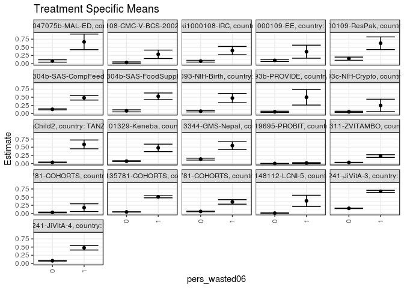

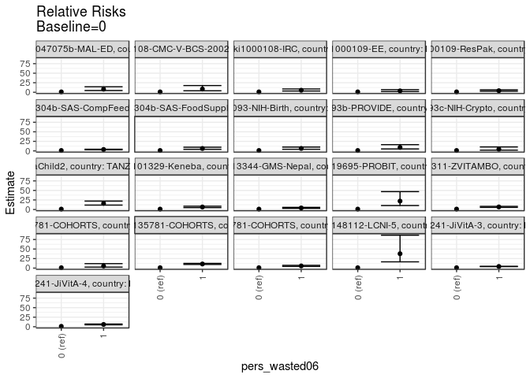

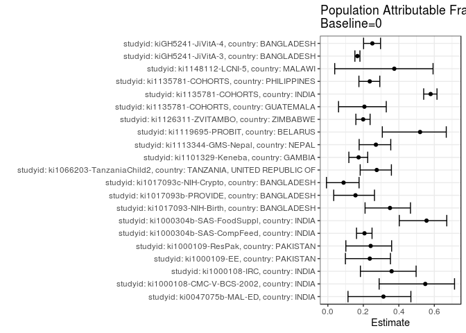

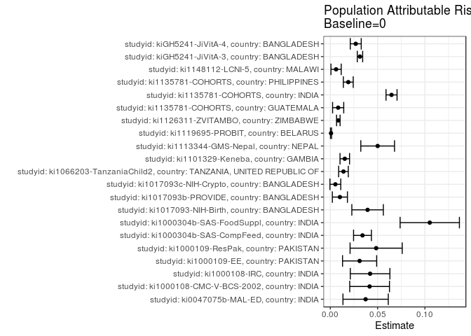

## Results Table

### Parameter: TSM

| studyid | country | intervention_level | baseline_level | estimate | ci_lower | ci_upper |
| --- | --- | --- | --- | --- | --- | --- |
| ki0047075b-MAL-ED | INDIA | 0 | NA | 0.0818182 | 0.0455227 | 0.1181136 |
| ki0047075b-MAL-ED | INDIA | 1 | NA | 0.6666667 | 0.4275982 | 0.9057351 |
| ki1000108-CMC-V-BCS-2002 | INDIA | 0 | NA | 0.0341285 | 0.0140004 | 0.0542567 |
| ki1000108-CMC-V-BCS-2002 | INDIA | 1 | NA | 0.2862172 | 0.1576454 | 0.4147891 |
| ki1000108-IRC | INDIA | 0 | NA | 0.0749998 | 0.0474012 | 0.1025983 |
| ki1000108-IRC | INDIA | 1 | NA | 0.4003538 | 0.2740083 | 0.5266994 |
| ki1000109-EE | PAKISTAN | 0 | NA | 0.1000427 | 0.0683954 | 0.1316900 |
| ki1000109-EE | PAKISTAN | 1 | NA | 0.3661479 | 0.1661985 | 0.5660974 |
| ki1000109-ResPak | PAKISTAN | 0 | NA | 0.1523810 | 0.1036692 | 0.2010927 |
| ki1000109-ResPak | PAKISTAN | 1 | NA | 0.6250000 | 0.4308989 | 0.8191011 |
| ki1000304b-SAS-CompFeed | INDIA | 0 | NA | 0.1307143 | 0.1160927 | 0.1453359 |
| ki1000304b-SAS-CompFeed | INDIA | 1 | NA | 0.4844115 | 0.4139448 | 0.5548781 |
| ki1000304b-SAS-FoodSuppl | INDIA | 0 | NA | 0.0839131 | 0.0525194 | 0.1153067 |
| ki1000304b-SAS-FoodSuppl | INDIA | 1 | NA | 0.5284769 | 0.4258315 | 0.6311223 |
| ki1017093-NIH-Birth | BANGLADESH | 0 | NA | 0.0731358 | 0.0500992 | 0.0961725 |
| ki1017093-NIH-Birth | BANGLADESH | 1 | NA | 0.4751263 | 0.3335945 | 0.6166580 |
| ki1017093b-PROVIDE | BANGLADESH | 0 | NA | 0.0549085 | 0.0366394 | 0.0731775 |
| ki1017093b-PROVIDE | BANGLADESH | 1 | NA | 0.5000000 | 0.2613176 | 0.7386824 |
| ki1017093c-NIH-Crypto | BANGLADESH | 0 | NA | 0.0549296 | 0.0381589 | 0.0717003 |
| ki1017093c-NIH-Crypto | BANGLADESH | 1 | NA | 0.2500000 | 0.0600972 | 0.4399028 |
| ki1066203-TanzaniaChild2 | TANZANIA, UNITED REPUBLIC OF | 0 | NA | 0.0366192 | 0.0283065 | 0.0449320 |
| ki1066203-TanzaniaChild2 | TANZANIA, UNITED REPUBLIC OF | 1 | NA | 0.5857172 | 0.4511549 | 0.7202795 |
| ki1101329-Keneba | GAMBIA | 0 | NA | 0.0730338 | 0.0622095 | 0.0838580 |
| ki1101329-Keneba | GAMBIA | 1 | NA | 0.4789803 | 0.3646991 | 0.5932616 |
| ki1113344-GMS-Nepal | NEPAL | 0 | NA | 0.1346921 | 0.1054296 | 0.1639546 |
| ki1113344-GMS-Nepal | NEPAL | 1 | NA | 0.5493881 | 0.4303515 | 0.6684248 |
| ki1119695-PROBIT | BELARUS | 0 | NA | 0.0006944 | 0.0001317 | 0.0012570 |
| ki1119695-PROBIT | BELARUS | 1 | NA | 0.0153129 | 0.0026160 | 0.0280098 |
| ki1126311-ZVITAMBO | ZIMBABWE | 0 | NA | 0.0341115 | 0.0305805 | 0.0376426 |
| ki1126311-ZVITAMBO | ZIMBABWE | 1 | NA | 0.2293665 | 0.1882969 | 0.2704360 |
| ki1135781-COHORTS | GUATEMALA | 0 | NA | 0.0320074 | 0.0208814 | 0.0431333 |
| ki1135781-COHORTS | GUATEMALA | 1 | NA | 0.1778188 | 0.0589687 | 0.2966689 |
| ki1135781-COHORTS | INDIA | 0 | NA | 0.0470071 | 0.0416485 | 0.0523656 |
| ki1135781-COHORTS | INDIA | 1 | NA | 0.5103268 | 0.4784322 | 0.5422214 |
| ki1135781-COHORTS | PHILIPPINES | 0 | NA | 0.0614743 | 0.0523061 | 0.0706424 |
| ki1135781-COHORTS | PHILIPPINES | 1 | NA | 0.3534396 | 0.2847421 | 0.4221371 |
| ki1148112-LCNI-5 | MALAWI | 0 | NA | 0.0102041 | 0.0031022 | 0.0173060 |
| ki1148112-LCNI-5 | MALAWI | 1 | NA | 0.3846154 | 0.2119598 | 0.5572710 |
| kiGH5241-JiVitA-3 | BANGLADESH | 0 | NA | 0.1566519 | 0.1504839 | 0.1628199 |
| kiGH5241-JiVitA-3 | BANGLADESH | 1 | NA | 0.6766217 | 0.6447353 | 0.7085081 |
| kiGH5241-JiVitA-4 | BANGLADESH | 0 | NA | 0.0803760 | 0.0710305 | 0.0897215 |
| kiGH5241-JiVitA-4 | BANGLADESH | 1 | NA | 0.4791464 | 0.4103794 | 0.5479135 |

### Parameter: E(Y)

| studyid | country | intervention_level | baseline_level | estimate | ci_lower | ci_upper |
| --- | --- | --- | --- | --- | --- | --- |
| ki0047075b-MAL-ED | INDIA | NA | NA | 0.1191489 | 0.0776405 | 0.1606574 |
| ki1000108-CMC-V-BCS-2002 | INDIA | NA | NA | 0.0756757 | 0.0486905 | 0.1026609 |
| ki1000108-IRC | INDIA | NA | NA | 0.1170732 | 0.0859146 | 0.1482317 |
| ki1000109-EE | PAKISTAN | NA | NA | 0.1310160 | 0.0967738 | 0.1652583 |
| ki1000109-ResPak | PAKISTAN | NA | NA | 0.2008547 | 0.1494120 | 0.2522974 |
| ki1000304b-SAS-CompFeed | INDIA | NA | NA | 0.1647399 | 0.1451050 | 0.1843747 |
| ki1000304b-SAS-FoodSuppl | INDIA | NA | NA | 0.1890547 | 0.1507312 | 0.2273783 |
| ki1017093-NIH-Birth | BANGLADESH | NA | NA | 0.1125461 | 0.0859151 | 0.1391771 |
| ki1017093b-PROVIDE | BANGLADESH | NA | NA | 0.0650407 | 0.0455353 | 0.0845460 |
| ki1017093c-NIH-Crypto | BANGLADESH | NA | NA | 0.0602740 | 0.0429977 | 0.0775502 |
| ki1066203-TanzaniaChild2 | TANZANIA, UNITED REPUBLIC OF | NA | NA | 0.0505451 | 0.0409848 | 0.0601054 |
| ki1101329-Keneba | GAMBIA | NA | NA | 0.0883377 | 0.0767324 | 0.0999430 |
| ki1113344-GMS-Nepal | NEPAL | NA | NA | 0.1847458 | 0.1534039 | 0.2160876 |
| ki1119695-PROBIT | BELARUS | NA | NA | 0.0014461 | 0.0004206 | 0.0024716 |
| ki1126311-ZVITAMBO | ZIMBABWE | NA | NA | 0.0425869 | 0.0387663 | 0.0464075 |
| ki1135781-COHORTS | GUATEMALA | NA | NA | 0.0403147 | 0.0282199 | 0.0524094 |
| ki1135781-COHORTS | INDIA | NA | NA | 0.1117237 | 0.1042858 | 0.1191617 |
| ki1135781-COHORTS | PHILIPPINES | NA | NA | 0.0804843 | 0.0704205 | 0.0905481 |
| ki1148112-LCNI-5 | MALAWI | NA | NA | 0.0163112 | 0.0075116 | 0.0251108 |
| kiGH5241-JiVitA-3 | BANGLADESH | NA | NA | 0.1880070 | 0.1814627 | 0.1945512 |
| kiGH5241-JiVitA-4 | BANGLADESH | NA | NA | 0.1072724 | 0.0967392 | 0.1178055 |

### Parameter: RR

| studyid | country | intervention_level | baseline_level | estimate | ci_lower | ci_upper |
| --- | --- | --- | --- | --- | --- | --- |
| ki0047075b-MAL-ED | INDIA | 0 | 0 | 1.000000 | 1.000000 | 1.000000 |
| ki0047075b-MAL-ED | INDIA | 1 | 0 | 8.148148 | 4.606020 | 14.414249 |
| ki1000108-CMC-V-BCS-2002 | INDIA | 0 | 0 | 1.000000 | 1.000000 | 1.000000 |
| ki1000108-CMC-V-BCS-2002 | INDIA | 1 | 0 | 8.386450 | 3.997310 | 17.594972 |
| ki1000108-IRC | INDIA | 0 | 0 | 1.000000 | 1.000000 | 1.000000 |
| ki1000108-IRC | INDIA | 1 | 0 | 5.338067 | 3.280878 | 8.685165 |
| ki1000109-EE | PAKISTAN | 0 | 0 | 1.000000 | 1.000000 | 1.000000 |
| ki1000109-EE | PAKISTAN | 1 | 0 | 3.659916 | 1.938553 | 6.909783 |
| ki1000109-ResPak | PAKISTAN | 0 | 0 | 1.000000 | 1.000000 | 1.000000 |
| ki1000109-ResPak | PAKISTAN | 1 | 0 | 4.101562 | 2.626572 | 6.404857 |
| ki1000304b-SAS-CompFeed | INDIA | 0 | 0 | 1.000000 | 1.000000 | 1.000000 |
| ki1000304b-SAS-CompFeed | INDIA | 1 | 0 | 3.705879 | 3.203988 | 4.286391 |
| ki1000304b-SAS-FoodSuppl | INDIA | 0 | 0 | 1.000000 | 1.000000 | 1.000000 |
| ki1000304b-SAS-FoodSuppl | INDIA | 1 | 0 | 6.297911 | 4.128110 | 9.608193 |
| ki1017093-NIH-Birth | BANGLADESH | 0 | 0 | 1.000000 | 1.000000 | 1.000000 |
| ki1017093-NIH-Birth | BANGLADESH | 1 | 0 | 6.496493 | 4.210055 | 10.024673 |
| ki1017093b-PROVIDE | BANGLADESH | 0 | 0 | 1.000000 | 1.000000 | 1.000000 |
| ki1017093b-PROVIDE | BANGLADESH | 1 | 0 | 9.106061 | 5.088919 | 16.294295 |
| ki1017093c-NIH-Crypto | BANGLADESH | 0 | 0 | 1.000000 | 1.000000 | 1.000000 |
| ki1017093c-NIH-Crypto | BANGLADESH | 1 | 0 | 4.551282 | 2.007191 | 10.319981 |
| ki1066203-TanzaniaChild2 | TANZANIA, UNITED REPUBLIC OF | 0 | 0 | 1.000000 | 1.000000 | 1.000000 |
| ki1066203-TanzaniaChild2 | TANZANIA, UNITED REPUBLIC OF | 1 | 0 | 15.994794 | 11.577731 | 22.097028 |
| ki1101329-Keneba | GAMBIA | 0 | 0 | 1.000000 | 1.000000 | 1.000000 |
| ki1101329-Keneba | GAMBIA | 1 | 0 | 6.558340 | 4.953660 | 8.682839 |
| ki1113344-GMS-Nepal | NEPAL | 0 | 0 | 1.000000 | 1.000000 | 1.000000 |
| ki1113344-GMS-Nepal | NEPAL | 1 | 0 | 4.078843 | 3.003786 | 5.538664 |
| ki1119695-PROBIT | BELARUS | 0 | 0 | 1.000000 | 1.000000 | 1.000000 |
| ki1119695-PROBIT | BELARUS | 1 | 0 | 22.053050 | 10.377204 | 46.865902 |
| ki1126311-ZVITAMBO | ZIMBABWE | 0 | 0 | 1.000000 | 1.000000 | 1.000000 |
| ki1126311-ZVITAMBO | ZIMBABWE | 1 | 0 | 6.724018 | 5.468989 | 8.267051 |
| ki1135781-COHORTS | GUATEMALA | 0 | 0 | 1.000000 | 1.000000 | 1.000000 |
| ki1135781-COHORTS | GUATEMALA | 1 | 0 | 5.555557 | 2.621447 | 11.773730 |
| ki1135781-COHORTS | INDIA | 0 | 0 | 1.000000 | 1.000000 | 1.000000 |
| ki1135781-COHORTS | INDIA | 1 | 0 | 10.856388 | 9.537309 | 12.357905 |
| ki1135781-COHORTS | PHILIPPINES | 0 | 0 | 1.000000 | 1.000000 | 1.000000 |
| ki1135781-COHORTS | PHILIPPINES | 1 | 0 | 5.749391 | 4.504192 | 7.338829 |
| ki1148112-LCNI-5 | MALAWI | 0 | 0 | 1.000000 | 1.000000 | 1.000000 |
| ki1148112-LCNI-5 | MALAWI | 1 | 0 | 37.692308 | 16.465322 | 86.284983 |
| kiGH5241-JiVitA-3 | BANGLADESH | 0 | 0 | 1.000000 | 1.000000 | 1.000000 |
| kiGH5241-JiVitA-3 | BANGLADESH | 1 | 0 | 4.319269 | 4.072444 | 4.581053 |
| kiGH5241-JiVitA-4 | BANGLADESH | 0 | 0 | 1.000000 | 1.000000 | 1.000000 |
| kiGH5241-JiVitA-4 | BANGLADESH | 1 | 0 | 5.961313 | 4.965166 | 7.157314 |

### Parameter: PAR

| studyid | country | intervention_level | baseline_level | estimate | ci_lower | ci_upper |
| --- | --- | --- | --- | --- | --- | --- |
| ki0047075b-MAL-ED | INDIA | 0 | NA | 0.0373308 | 0.0133773 | 0.0612842 |
| ki1000108-CMC-V-BCS-2002 | INDIA | 0 | NA | 0.0415471 | 0.0205384 | 0.0625559 |
| ki1000108-IRC | INDIA | 0 | NA | 0.0420734 | 0.0211353 | 0.0630115 |
| ki1000109-EE | PAKISTAN | 0 | NA | 0.0309733 | 0.0129269 | 0.0490197 |
| ki1000109-ResPak | PAKISTAN | 0 | NA | 0.0484737 | 0.0209011 | 0.0760464 |
| ki1000304b-SAS-CompFeed | INDIA | 0 | NA | 0.0340256 | 0.0245818 | 0.0434693 |
| ki1000304b-SAS-FoodSuppl | INDIA | 0 | NA | 0.1051417 | 0.0738031 | 0.1364802 |
| ki1017093-NIH-Birth | BANGLADESH | 0 | NA | 0.0394103 | 0.0227493 | 0.0560713 |
| ki1017093b-PROVIDE | BANGLADESH | 0 | NA | 0.0101322 | 0.0021706 | 0.0180938 |
| ki1017093c-NIH-Crypto | BANGLADESH | 0 | NA | 0.0053444 | -0.0003673 | 0.0110561 |
| ki1066203-TanzaniaChild2 | TANZANIA, UNITED REPUBLIC OF | 0 | NA | 0.0139259 | 0.0088214 | 0.0190303 |
| ki1101329-Keneba | GAMBIA | 0 | NA | 0.0153039 | 0.0102675 | 0.0203403 |
| ki1113344-GMS-Nepal | NEPAL | 0 | NA | 0.0500536 | 0.0322345 | 0.0678727 |
| ki1119695-PROBIT | BELARUS | 0 | NA | 0.0007518 | 0.0001694 | 0.0013341 |
| ki1126311-ZVITAMBO | ZIMBABWE | 0 | NA | 0.0084754 | 0.0066219 | 0.0103289 |
| ki1135781-COHORTS | GUATEMALA | 0 | NA | 0.0083073 | 0.0024188 | 0.0141957 |
| ki1135781-COHORTS | INDIA | 0 | NA | 0.0647167 | 0.0588804 | 0.0705530 |
| ki1135781-COHORTS | PHILIPPINES | 0 | NA | 0.0190101 | 0.0137927 | 0.0242275 |
| ki1148112-LCNI-5 | MALAWI | 0 | NA | 0.0061071 | 0.0006741 | 0.0115401 |
| kiGH5241-JiVitA-3 | BANGLADESH | 0 | NA | 0.0313550 | 0.0285127 | 0.0341974 |
| kiGH5241-JiVitA-4 | BANGLADESH | 0 | NA | 0.0268964 | 0.0211021 | 0.0326907 |

### Parameter: PAF

| studyid | country | intervention_level | baseline_level | estimate | ci_lower | ci_upper |
| --- | --- | --- | --- | --- | --- | --- |
| ki0047075b-MAL-ED | INDIA | 0 | NA | 0.3133117 | 0.1136573 | 0.4679927 |
| ki1000108-CMC-V-BCS-2002 | INDIA | 0 | NA | 0.5490158 | 0.2891398 | 0.7138864 |
| ki1000108-IRC | INDIA | 0 | NA | 0.3593769 | 0.1834856 | 0.4973782 |
| ki1000109-EE | PAKISTAN | 0 | NA | 0.2364087 | 0.0990690 | 0.3528120 |
| ki1000109-ResPak | PAKISTAN | 0 | NA | 0.2413374 | 0.1014563 | 0.3594424 |
| ki1000304b-SAS-CompFeed | INDIA | 0 | NA | 0.2065412 | 0.1616542 | 0.2490249 |
| ki1000304b-SAS-FoodSuppl | INDIA | 0 | NA | 0.5561441 | 0.4025995 | 0.6702245 |
| ki1017093-NIH-Birth | BANGLADESH | 0 | NA | 0.3501703 | 0.2097085 | 0.4656672 |
| ki1017093b-PROVIDE | BANGLADESH | 0 | NA | 0.1557820 | 0.0331417 | 0.2628662 |
| ki1017093c-NIH-Crypto | BANGLADESH | 0 | NA | 0.0886684 | -0.0078075 | 0.1759087 |
| ki1066203-TanzaniaChild2 | TANZANIA, UNITED REPUBLIC OF | 0 | NA | 0.2755135 | 0.1822302 | 0.3581559 |
| ki1101329-Keneba | GAMBIA | 0 | NA | 0.1732433 | 0.1184327 | 0.2246462 |
| ki1113344-GMS-Nepal | NEPAL | 0 | NA | 0.2709324 | 0.1764384 | 0.3545843 |
| ki1119695-PROBIT | BELARUS | 0 | NA | 0.5198465 | 0.3069952 | 0.6673221 |
| ki1126311-ZVITAMBO | ZIMBABWE | 0 | NA | 0.1990138 | 0.1579669 | 0.2380597 |
| ki1135781-COHORTS | GUATEMALA | 0 | NA | 0.2060610 | 0.0603030 | 0.3292102 |
| ki1135781-COHORTS | INDIA | 0 | NA | 0.5792564 | 0.5401187 | 0.6150633 |
| ki1135781-COHORTS | PHILIPPINES | 0 | NA | 0.2361958 | 0.1751056 | 0.2927618 |
| ki1148112-LCNI-5 | MALAWI | 0 | NA | 0.3744113 | 0.0387300 | 0.5928707 |
| kiGH5241-JiVitA-3 | BANGLADESH | 0 | NA | 0.1667760 | 0.1524564 | 0.1808537 |
| kiGH5241-JiVitA-4 | BANGLADESH | 0 | NA | 0.2507298 | 0.2014505 | 0.2969680 |